# Natural-language-Processing (R)

Daniel S. Hain (dsh@business.aau.dk)

Updated October 26, 2020

```r
### Load standardpackages
library(tidyverse) # Collection of all the good stuff like dplyr, ggplot2 ect.
library(magrittr) # For extra-piping operators (eg. %<>%)
```

### This session

# Exploring ‘Crime and Punishment’

Let’s raise the bar with some **Fyodor Dostoevsky**

[figure not shown]

```r
library(tidytext)
```

## Download Data

```r
# We first need to get the book text. It can be conveniently retrieved via the gutenbergr library, linking r to the Gutenberg project
library(gutenbergr)
```

```r
# check the id of crime and punishment
gutenberg_metadata %>%
  filter(title == "Crime and Punishment")
```

| gutenberg_id | title | author | gutenberg_author_id | language | gutenberg_bookshelf | rights | has_text |
| --- | --- | --- | --- | --- | --- | --- | --- |
| 2554 | Crime and Punishment | Dostoyevsky, Fyodor | 314 | en | Best Books Ever Listings/Crime Fiction/Harvard Classics | Public domain in the USA. | TRUE |

```r
text_raw <- gutenberg_download(2554)
```

```r
text_raw %>% glimpse()
```

```
Rows: 22,061
Columns: 2
$ gutenberg_id <int> 2554, 2554, 2554, 2554, 2554, 2554, 2554, 2554, 2554, 2554, 2554, 2554, 2554, 2554, …
$ text         <chr> "CRIME AND PUNISHMENT", "", "By Fyodor Dostoevsky", "", "", "", "Translated By Const…
```

```r
# LEts take a look
text_raw %>% head(200)
```

| gutenberg_id | text |
| --- | --- |
| 2554 | CRIME AND PUNISHMENT |
| 2554 |  |
| 2554 | By Fyodor Dostoevsky |
| 2554 |  |
| 2554 |  |
| 2554 |  |
| 2554 | Translated By Constance Garnett |
| 2554 |  |
| 2554 |  |
| 2554 |  |

[output cut: 190 more lines]

## Preprocessing

- We see the data is read in by line rather than one cell per book/chapter, or paragraph.
- We also see all original line breaks are contained, including empty lines
- The real book starts at line 102
- The parts and chapters are assigned, info we can probably use.
- to create IDs for the text chunks, we could use the linenumber
- Then we could already get rid of empty and chapter lines

```r
text <- text_raw %>%
  select(-gutenberg_id) %>%
  slice(-c(1:102)) %>%
  mutate(line_num = row_number(),# create new variable line_num
         part = cumsum(str_detect(text, regex("^PART [\\divxlc]",
                                                  ignore_case = TRUE)))) %>% # create variable part: Crime and Punishment has 7 parts %>%
         group_by(part) %>%
         mutate(chapter = cumsum(str_detect(text, regex("^CHAPTER [\\divxlc]",
                                                          ignore_case = TRUE)))) %>% # create new variable number of Chapter per part %>%
         ungroup() %>%
  filter(text != "" & !str_detect(text, regex("^[PART|CHAPTER]"))) %>%
  mutate(index = 1:n()) %>%
  relocate(index, line_num, part, chapter, text)
```

```r
text %>% glimpse()
```

```
Rows: 16,548
Columns: 5
$ index    <int> 1, 2, 3, 4, 5, 6, 7, 8, 9, 10, 11, 12, 13, 14, 15, 16, 17, 18, 19, 20, 21, 22, 23, 24, 2…
$ line_num <int> 7, 8, 9, 12, 13, 14, 15, 16, 17, 18, 21, 22, 23, 24, 25, 26, 27, 28, 29, 30, 31, 32, 35,…
$ part     <int> 1, 1, 1, 1, 1, 1, 1, 1, 1, 1, 1, 1, 1, 1, 1, 1, 1, 1, 1, 1, 1, 1, 1, 1, 1, 1, 1, 1, 1, 1…
$ chapter  <int> 1, 1, 1, 1, 1, 1, 1, 1, 1, 1, 1, 1, 1, 1, 1, 1, 1, 1, 1, 1, 1, 1, 1, 1, 1, 1, 1, 1, 1, 1…
$ text     <chr> "On an exceptionally hot evening early in July a young man came out of", "the garret in …
```

Cool!

```r
text_tidy <- text %>% unnest_tokens(word, text, token = 'words') %>%
  anti_join(stop_words, by = 'word')
```

```r
text_tidy %>% head(10)
```

| index | line_num | part | chapter | word |
| --- | --- | --- | --- | --- |
| 1 | 7 | 1 | 1 | exceptionally |
| 1 | 7 | 1 | 1 | hot |
| 1 | 7 | 1 | 1 | evening |
| 1 | 7 | 1 | 1 | july |
| 2 | 8 | 1 | 1 | garret |
| 2 | 8 | 1 | 1 | lodged |
| 2 | 8 | 1 | 1 | walked |
| 2 | 8 | 1 | 1 | slowly |
| 3 | 9 | 1 | 1 | hesitation |
| 3 | 9 | 1 | 1 | bridge |

## Stemming

- We will not use it here a lot, but consider stemming as a possible pre-processing option.
- Here, words will be reduced to their common word-stem, eg. words like “analysis”, “analyze”, “analyzing” etc. will all be reduced to “analyz”
- This sometimes makes it easier to work with word token, however, also is sometimes to aggresive and reduces interpretability.

```r
library(SnowballC) # Includes stemming algos
```

```r
text_tidy %>%
  mutate(stem = wordStem(word)) %>%
  head(10)
```

| index | line_num | part | chapter | word | stem |
| --- | --- | --- | --- | --- | --- |
| 1 | 7 | 1 | 1 | exceptionally | exception |
| 1 | 7 | 1 | 1 | hot | hot |
| 1 | 7 | 1 | 1 | evening | even |
| 1 | 7 | 1 | 1 | july | juli |
| 2 | 8 | 1 | 1 | garret | garret |
| 2 | 8 | 1 | 1 | lodged | lodg |
| 2 | 8 | 1 | 1 | walked | walk |
| 2 | 8 | 1 | 1 | slowly | slowli |
| 3 | 9 | 1 | 1 | hesitation | hesit |
| 3 | 9 | 1 | 1 | bridge | bridg |

```r
text_tidy %>%
  mutate(stem = wordStem(word)) %>%
  count(stem, sort = TRUE) %>%
  head(50)
```

| stem | n |
| --- | --- |
| raskolnikov | 473 |
| time | 417 |
| dai | 339 |
| sonia | 339 |
| hand | 296 |
| dounia | 278 |
| suddenli | 263 |
| razumihin | 249 |
| ivanovna | 241 |
| cri | 238 |

[output cut: 40 more lines]

# First exploration

## Topwords

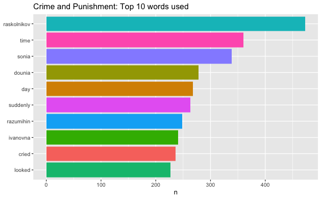

```r
# top 10 words used in Crime and Punishment
text_tidy %>%
  count(word, sort = TRUE) %>%
  slice(1:10) %>%
  ggplot(aes(x = fct_reorder(word, n), y = n, fill = word)) +
  geom_col(show.legend = FALSE) +
  coord_flip() +
  labs(title = "Crime and Punishment: Top 10 words used", x = NULL)
```

- Unsurprisingly, the word used more often corresponds to the name of the main character, Raskolnikov.
- We can also use a word cloud:

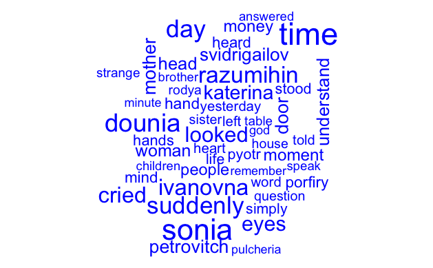

```r
# People love wordclouds
library(wordcloud)

text_tidy %>%
  count(word) %>%
  with(wordcloud(word, n,
                 max.words = 50,
                 color = "blue"))
```

## Sentiment Analysis

- While interesting, word frequency does not tell us much about the emotions/states of mind present in the novel.
- For this reason, we will go ahead with a sentiment analysis of “Crime and Punishment”
- While sounding very comlpex, sentiment analysis is usually done in a rather simple way.
- There are already predefined sentiment lexica around, linking words ith certain sentiments
- So we do have to only join our word-token with the corresponding sentiments
- The most popular dictionaries available are
  1. “bing”: classifies words binary into positive and negative sentiment
  2. “nrc” has the following emotion categories: positive, negative, anger, anticipation, disgust, fear, joy, sadness, surprise, and trust; and
  3. “afinn” corresponds to a sentiment score from -5 (very negative) to 5 (very positive).

```r
# You might need to first install the 'textdata' package for some of the lexica
get_sentiments("bing") %>%
  head(20)
```

| word | sentiment |
| --- | --- |
| 2-faces | negative |
| abnormal | negative |
| abolish | negative |
| abominable | negative |
| abominably | negative |
| abominate | negative |
| abomination | negative |
| abort | negative |
| aborted | negative |
| aborts | negative |

[output cut: 10 more lines]

Lets calculate them all

```r
sentiment_bing <- text_tidy %>%
  inner_join(get_sentiments("bing")) %>%
  count(chapter, index = index %/% 100, sentiment) %>% # index of 100 lines of text
  mutate(lexicon = 'Bing')

sentiment_nrc <- text_tidy %>%
  inner_join(get_sentiments("nrc")) %>%
  count(chapter, index = index %/% 100, sentiment) %>% # index of 100 lines of text
  mutate(lexicon = 'NRC')

sentiment_afinn <- text_tidy %>%
  select(-line_num, -part) %>%
  inner_join(get_sentiments("afinn")) %>%
  group_by(index = index %/% 100)  %>% # index of 100 lines of text
  summarise(sentiment = sum(value, na.rm = TRUE)) %>%
  mutate(lexicon = 'AFINN')
```

```r
# Lets join them all together for plotting
sentiment_all <- sentiment_afinn %>%
  bind_rows(sentiment_bing %>%
              pivot_wider(names_from = sentiment, values_from = n, values_fill = 0) %>%
              mutate(sentiment = positive - negative) %>%
              select(index, sentiment, lexicon) ) %>%
    bind_rows(sentiment_nrc %>%
              pivot_wider(names_from = sentiment, values_from = n, values_fill = 0) %>%
              mutate(sentiment = positive - negative) %>%
              select(index, sentiment, lexicon) )
```

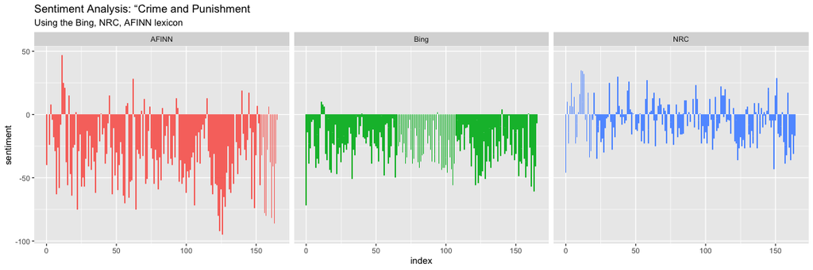

```r
# crime and punishment -
sentiment_all %>%
  ggplot(aes(x = index, y = sentiment, fill = lexicon)) +
  geom_col(show.legend = FALSE) +
  facet_wrap(~ lexicon) +
  labs(title = "Sentiment Analysis: “Crime and Punishment",
       subtitle = 'Using the Bing, NRC, AFINN lexicon')
```

- Since NRS also provides us with options to dive deeper into specific, rather than only positive and negative sentiments.

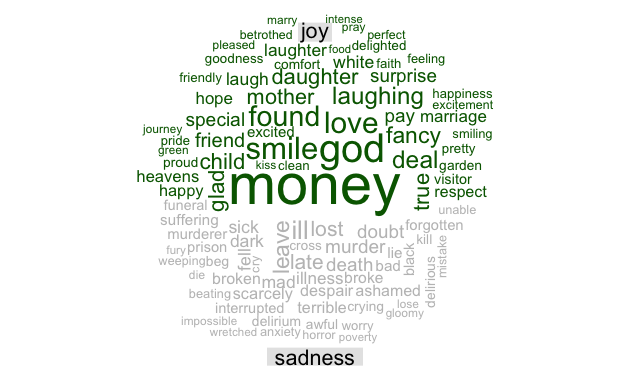

```r
text_tidy %>%
  inner_join(get_sentiments("nrc")) %>%
  count(word, sentiment, sort = TRUE) %>%
  filter(sentiment %in% c("joy", "sadness")) %>%
  pivot_wider(names_from = sentiment, values_from = n, values_fill = 0) %>%
  as.data.frame() %>%
  remove_rownames() %>%
  column_to_rownames("word") %>%
  comparison.cloud(colors = c("darkgreen", "grey75"),
                   max.words = 100,
                   title.size = 1.5)
```

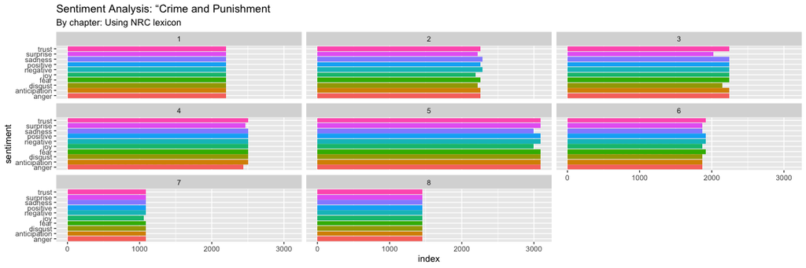

```r
# crime and punishment -
sentiment_nrc %>%
  ggplot(aes(x = index, y = sentiment, fill = sentiment)) +
  geom_col(show.legend = FALSE) +
  facet_wrap(~ chapter) +
  labs(title = "Sentiment Analysis: “Crime and Punishment",
       subtitle = 'By chapter: Using NRC lexicon')
```

### Word network

- Obviously, we already have to sprinkle in some networks here
- The easiest way would bee to look t words that frequently occur together.
- We could do that in a more complicated way, but since we already have the line-nubmer, why not start with creating edges between words in the same line?
- `tidytext` had an amazing function `pairwise_count` for that. However, since it is of more general use, the developers outsourced it into the not-text-specific `widyr` package, which they also maintain.

```r
library(widyr)
el_words <- text_tidy %>%
  pairwise_count(word, index, sort = TRUE) %>%
  rename(from = item1, to = item2, weight = n)
```

```r
el_words %>% head()
```

| from | to | weight |
| --- | --- | --- |
| katerina | ivanovna | 152 |
| ivanovna | katerina | 152 |
| petrovitch | pyotr | 108 |
| pyotr | petrovitch | 108 |
| romanovna | avdotya | 77 |
| avdotya | romanovna | 77 |

```r
library(tidygraph)
library(ggraph)
```

```r
g <- el_words %>%
  filter(weight >= 9) %>%
  as_tbl_graph(directed = FALSE) %>%
  igraph::simplify() %>% as_tbl_graph()
```

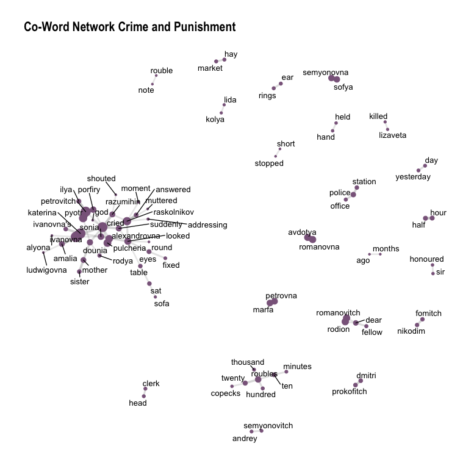

```r
set.seed(1337)
g %N>%
#  filter(centrality_degree(weight = weight) > 100) %>%
  ggraph(layout = "fr") +
  geom_edge_link(aes(width = weight, edge_alpha = weight)) +
  geom_node_point(aes(size = centrality_degree(weight = weight)), color = "plum4") +
  geom_node_text(aes(label = name,), repel = TRUE) +
  theme_graph() +
  theme(legend.position = 'none') +
  labs(title = 'Co-Word Network Crime and Punishment')
```

# Endnotes

### Main reference

- Julia Silge and David Robinson (2020). Text Mining with R: A Tidy Approach, O’Reilly. Online available [here](https://www.tidytextmining.com/)
  - [Chapter 2](https://www.tidytextmining.com/sentiment.html): Introduction to sentiment analysis
- Emil Hvidfeldt and Julia Silge (2020). Supervised Machine Learning for Text Analysis in R, online available [here](https://smltar.com/)
  - [Chapter 4](https://smltar.com/stemming.html): Stemming

### Packages & Ecosystem

- [`tidytext`](https://github.com/juliasilge/tidytext)

further: * [`rtweet`](https://github.com/ropensci/rtweet): R interface to the twitter API.

### Suggestions for further study

- DataCamp (!Most courses have somewhat outdated ecosystems)
  - [Introduction to Text Analysis in R](https://learn.datacamp.com/courses/introduction-to-text-analysis-in-r): The basics of text analysis in R
  - [Introduction to Natural Language Processing in R](https://learn.datacamp.com/courses/introduction-to-natural-language-processing-in-r): Some refresher plus more advanced applications in the end.